# Fast Metric Kernel Density

SHMTools Example - Non_Parametric_Detectors

← Back to Index [GitHub Repository](https://github.com/shmtools/shmtools-python) [Documentation](https://shmtools.readthedocs.io)

# Example Usage: Fast Metric Kernel Density Estimation

## Introduction

Distance metrics play an important role in nonparametric density estimation. In kernel density estimation, the notion of distance used is typically the Euclidean l2 norm: the density at a point x is roughly estimated as the proportion of points that fall in a Euclidean ball B(x, h) divided by the volume of this ball. Instead of using a Euclidean ball, we might use a different metric which we deem more "natural" for our particular application.

Here we show how to use the "Fast Metric Kernel Estimation" modules to accomplish this. These modules are implemented using tree-based data structures which enable fast estimation of the density at x. The datastructure allows us to avoid computing the distance from x to every training point (in order to identify the points that fall in the ball B(x, h)), and instead arranges the training points hierarchically so that one only need to check the distances to some of the points. Note that this is a large datastructure and needs to reside in memory if we want to obtain speedups, otherwise loading time becomes the bottleneck.

We note however that in Python, vectorized operations are usually faster than loops, and this fact can be used to compute L2 distances faster by taking advantage of its relation to inner products. The modules in "Fast Metric Kernel Estimation" therefore are mainly useful when using a distance metric that cannot be implemented fast through matrix operations.

To learn more on tree-based data structures, we refer the user to the following references on fast proximity search methods:

**References:**

- Samory Kpotufe. Fast, smooth and adaptive regression in metric spaces. NIPS 2009.
- A. Beygelzimer, S. Kakade, and J. Langford. Cover trees for nearest neighbors. ICML, 2006.
- R. Krauthgamer and J. Lee. Navigating nets: Simple algorithms for proximity search. SODA, 2004.

**SHMTools functions called:**

- `learn_fast_metric_kernel_density_shm`
- `score_fast_metric_kernel_density_shm`

```python
# Import required libraries
import numpy as np
import matplotlib.pyplot as plt
from mpl_toolkits.mplot3d import Axes3D
import time

# Import shmtools functions
from shmtools.classification import (
    learn_fast_metric_kernel_density_shm,
    score_fast_metric_kernel_density_shm
)

# Set random seed for reproducibility
np.random.seed(42)

# Configure matplotlib
plt.style.use('default')
plt.rcParams['figure.figsize'] = (10, 8)
plt.rcParams['font.size'] = 12
```

## Training data

The data will be drawn out of a mixture of two gaussians in R^2.

```
Training data shape: (700, 2)
Data dimension: 2
Number of training points: 700
```

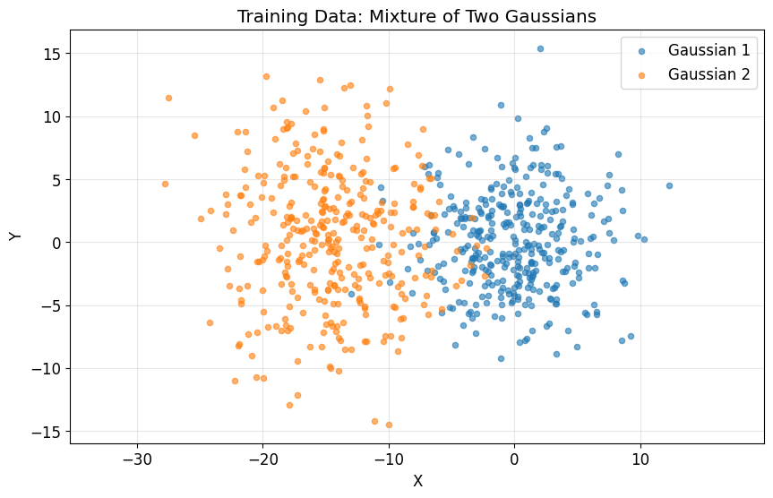

```python
# Training data parameters
D = 2  # Dimension
m = 700  # Number of training points

# Generate mixture of two gaussians
Xtrain_part1 = 4 * np.random.randn(m//2, D)
Xtrain_part2 = 5 * np.random.randn(m//2, D) + np.array([[-15, 0]])
Xtrain = np.vstack([Xtrain_part1, Xtrain_part2])

print(f"Training data shape: {Xtrain.shape}")
print(f"Data dimension: {D}")
print(f"Number of training points: {m}")

# Visualize training data
plt.figure(figsize=(10, 6))
plt.scatter(Xtrain_part1[:, 0], Xtrain_part1[:, 1], alpha=0.6, s=20, label='Gaussian 1')
plt.scatter(Xtrain_part2[:, 0], Xtrain_part2[:, 1], alpha=0.6, s=20, label='Gaussian 2')
plt.xlabel('X')
plt.ylabel('Y')
plt.title('Training Data: Mixture of Two Gaussians')
plt.legend()
plt.grid(True, alpha=0.3)
plt.axis('equal')
plt.show()
```

## Build the model

Here we build two models, one using an l1 metric (Manhattan distance), and the other using an l2 Euclidean metric and later compare the results.

```python
# Model parameters
# Not supplying h forces learner to use default bandwidth
h = None  # Will use default bandwidth selection

# Use Epanechnikov kernel (equivalent to kernelType = 2 in MATLAB)
kernelType = 'tophat'  # Closest equivalent to the triangle/epanechnikov family

# Build the L1 (Manhattan) model
print("Building fast L1 (Manhattan) model...")
start_time = time.time()
fastL1Model = learn_fast_metric_kernel_density_shm(
    Xtrain,
    bw=1.0,  # Default bandwidth
    kernel=kernelType,
    metric='manhattan'
)
l1_train_time = time.time() - start_time
print(f"L1 model training time: {l1_train_time:.3f} seconds")

# Build the L2 (Euclidean) model
print("\nBuilding fast L2 (Euclidean) model...")
start_time = time.time()
fastL2Model = learn_fast_metric_kernel_density_shm(
    Xtrain,
    bw=1.0,  # Default bandwidth
    kernel=kernelType,
    metric='euclidean'
)
l2_train_time = time.time() - start_time
print(f"L2 model training time: {l2_train_time:.3f} seconds")
```

```
Building fast L1 (Manhattan) model...
L1 model training time: 0.020 seconds

Building fast L2 (Euclidean) model...
L2 model training time: 0.000 seconds
```

## Test data

We pick uniformly from a grid over the R^2 plane

```python
# Create test grid
x_range = np.arange(-40, 41)  # -40 to 40
y_range = np.arange(-40, 41)  # -40 to 40
x_grid, y_grid = np.meshgrid(x_range, y_range)
n = x_grid.shape[0]

# Flatten grid into test points
X = np.column_stack([x_grid.ravel(), y_grid.ravel()])

print(f"Test grid size: {n} x {n}")
print(f"Total test points: {X.shape[0]}")
print(f"Test data shape: {X.shape}")
```

```
Test grid size: 81 x 81
Total test points: 6561
Test data shape: (6561, 2)
```

## Score on the test points

The scoring functions below will return the log of the density at each test point. We record the time to compare it against the naive way of doing kernel density estimation, i.e. by computing the distance to all training points.

```python
# Score with fast L1 model
print("Scoring with fast L1 model...")
start_time = time.time()
fastL1Z = score_fast_metric_kernel_density_shm(X, fastL1Model)
fastL1Time = time.time() - start_time
print(f"Fast L1 scoring time: {fastL1Time:.3f} seconds")

# Score with fast L2 model
print("\nScoring with fast L2 model...")
start_time = time.time()
fastL2Z = score_fast_metric_kernel_density_shm(X, fastL2Model)
fastL2Time = time.time() - start_time
print(f"Fast L2 scoring time: {fastL2Time:.3f} seconds")
```

```
Scoring with fast L1 model...
Fast L1 scoring time: 0.002 seconds

Scoring with fast L2 model...
Fast L2 scoring time: 0.002 seconds
```

## Naive kernel density estimation

Now we do the estimation by the "naive" implementation where we just compute the distance to all points and use a kernel, using a bandwidth parameter h = 6 (pre-picked as a good one over this particular data). Here again we use the l1 distance of earlier.

```python
def lk_dist(x, training_points, k=1):
    """
    Compute Lk distances from a single point x to all training points.

    Parameters:
    x: single test point (1D array)
    training_points: training data (2D array)
    k: norm type (1 for L1/Manhattan, 2 for L2/Euclidean)
    """
    if k == 1:
        # L1 (Manhattan) distance
        return np.sum(np.abs(x - training_points), axis=1)
    elif k == 2:
        # L2 (Euclidean) distance
        return np.sqrt(np.sum((x - training_points)**2, axis=1))
    else:
        # General Lk norm
        return np.power(np.sum(np.power(np.abs(x - training_points), k), axis=1), 1.0/k)

def metric_kernel(distances, kernel_type=2):
    """
    Compute kernel weights from distances.

    Parameters:
    distances: array of distances
    kernel_type: 1=triangle, 2=epanechnikov, 3=quartic, 4=triweight
    """
    distances = np.asarray(distances)

    if kernel_type == 1:
        # Triangle kernel: (1-d)+
        weights = np.maximum(1 - distances, 0)
    elif kernel_type == 2:
        # Epanechnikov kernel: (1-d^2)+
        weights = np.maximum(1 - distances**2, 0)
    elif kernel_type == 3:
        # Quartic kernel: ((1-d^2)+)^2
        weights = np.maximum(1 - distances**2, 0)**2
    elif kernel_type == 4:
        # Triweight kernel: ((1-d^2)+)^3
        weights = np.maximum(1 - distances**2, 0)**3
    else:
        raise ValueError(f"Unknown kernel type: {kernel_type}")

    return weights

# Naive implementation with L1 distance
h = 6  # Bandwidth parameter
naiveL1Z = np.zeros(X.shape[0])

print("Computing naive L1 kernel density estimation...")
print(f"This may take a while for {X.shape[0]} test points...")

start_time = time.time()
for i in range(X.shape[0]):
    if i % 1000 == 0:
        print(f"  Processing point {i}/{X.shape[0]}")

    # Compute L1 distances from test point to all training points
    dist = lk_dist(X[i, :], Xtrain, k=1)

    # Apply kernel with bandwidth scaling
    weights = metric_kernel(dist / h, kernel_type=2)

    # Density estimate
    naiveL1Z[i] = np.sum(weights) / (m * h**D)

naiveL1Time = time.time() - start_time

print(f"\nFast L1 Time: {fastL1Time:.2f} s, Naive L1 Time: {naiveL1Time:.2f} s")
print(f"Speedup: {naiveL1Time/fastL1Time:.1f}x")
```

```
Computing naive L1 kernel density estimation...
This may take a while for 6561 test points...
  Processing point 0/6561
  Processing point 1000/6561
  Processing point 2000/6561
  Processing point 3000/6561
  Processing point 4000/6561
  Processing point 5000/6561
  Processing point 6000/6561

Fast L1 Time: 0.00 s, Naive L1 Time: 0.08 s
Speedup: 36.8x
```

## Plot the estimated densities

Put Z in the right format for meshing, and plot.

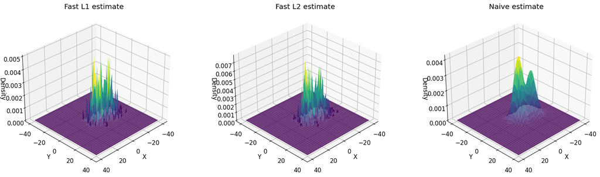

```python
# Reshape the density estimates back to grid format
l1z = np.exp(fastL1Z).reshape(n, n)
l2z = np.exp(fastL2Z).reshape(n, n)
naivez = naiveL1Z.reshape(n, n)

# Create 3D mesh plots
fig = plt.figure(figsize=(18, 5))

# Fast L1 estimate
ax1 = fig.add_subplot(131, projection='3d')
surf1 = ax1.plot_surface(x_grid, y_grid, l1z, cmap='viridis', alpha=0.8)
ax1.set_xlabel('X')
ax1.set_ylabel('Y')
ax1.set_zlabel('Density')
ax1.set_title('Fast L1 estimate')
ax1.view_init(elev=30, azim=45)

# Fast L2 estimate
ax2 = fig.add_subplot(132, projection='3d')
surf2 = ax2.plot_surface(x_grid, y_grid, l2z, cmap='viridis', alpha=0.8)
ax2.set_xlabel('X')
ax2.set_ylabel('Y')
ax2.set_zlabel('Density')
ax2.set_title('Fast L2 estimate')
ax2.view_init(elev=30, azim=45)

# Naive estimate
ax3 = fig.add_subplot(133, projection='3d')
surf3 = ax3.plot_surface(x_grid, y_grid, naivez, cmap='viridis', alpha=0.8)
ax3.set_xlabel('X')
ax3.set_ylabel('Y')
ax3.set_zlabel('Density')
ax3.set_title('Naive estimate')
ax3.view_init(elev=30, azim=45)

plt.tight_layout()
plt.show()
```

## Contour plots for better visualization

Let's also create contour plots to better visualize the density estimates and compare them.

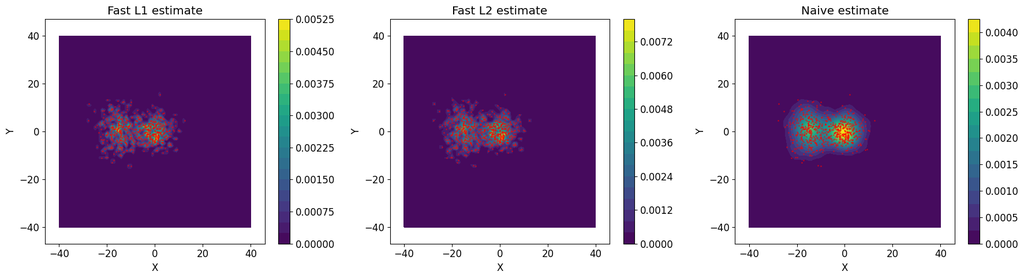

```python
# Create contour plots
fig, axes = plt.subplots(1, 3, figsize=(18, 5))

# Fast L1 estimate contour
contour1 = axes[0].contourf(x_grid, y_grid, l1z, levels=20, cmap='viridis')
axes[0].scatter(Xtrain[:, 0], Xtrain[:, 1], s=1, c='red', alpha=0.5)
axes[0].set_xlabel('X')
axes[0].set_ylabel('Y')
axes[0].set_title('Fast L1 estimate')
axes[0].axis('equal')
plt.colorbar(contour1, ax=axes[0])

# Fast L2 estimate contour
contour2 = axes[1].contourf(x_grid, y_grid, l2z, levels=20, cmap='viridis')
axes[1].scatter(Xtrain[:, 0], Xtrain[:, 1], s=1, c='red', alpha=0.5)
axes[1].set_xlabel('X')
axes[1].set_ylabel('Y')
axes[1].set_title('Fast L2 estimate')
axes[1].axis('equal')
plt.colorbar(contour2, ax=axes[1])

# Naive estimate contour
contour3 = axes[2].contourf(x_grid, y_grid, naivez, levels=20, cmap='viridis')
axes[2].scatter(Xtrain[:, 0], Xtrain[:, 1], s=1, c='red', alpha=0.5)
axes[2].set_xlabel('X')
axes[2].set_ylabel('Y')
axes[2].set_title('Naive estimate')
axes[2].axis('equal')
plt.colorbar(contour3, ax=axes[2])

plt.tight_layout()
plt.show()
```

## Performance Comparison

Let's compare the computational performance and accuracy of the different methods.

```
=== Performance Summary ===
Training data size: 700 points in 2D
Test grid size: 81 x 81 = 6561 points

Training times:
  Fast L1 model: 0.020 seconds
  Fast L2 model: 0.000 seconds

Scoring times:
  Fast L1 scoring: 0.002 seconds
  Fast L2 scoring: 0.002 seconds
  Naive L1 scoring: 0.079 seconds

Speedup (Naive/Fast L1): 36.8x

=== Accuracy Comparison (Fast L1 vs Naive L1) ===
Correlation coefficient: 0.8577
RMSE: 0.000274
Maximum absolute difference: 0.003747
```

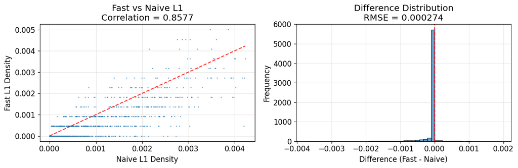

```python
# Performance summary
print("=== Performance Summary ===")
print(f"Training data size: {m} points in {D}D")
print(f"Test grid size: {n} x {n} = {X.shape[0]} points")
print()
print("Training times:")
print(f"  Fast L1 model: {l1_train_time:.3f} seconds")
print(f"  Fast L2 model: {l2_train_time:.3f} seconds")
print()
print("Scoring times:")
print(f"  Fast L1 scoring: {fastL1Time:.3f} seconds")
print(f"  Fast L2 scoring: {fastL2Time:.3f} seconds")
print(f"  Naive L1 scoring: {naiveL1Time:.3f} seconds")
print()
print(f"Speedup (Naive/Fast L1): {naiveL1Time/fastL1Time:.1f}x")

# Accuracy comparison (compare fast L1 vs naive L1)
# Convert log densities to densities for comparison
fast_l1_density = np.exp(fastL1Z)
naive_l1_density = naiveL1Z

# Compute correlation and RMSE
correlation = np.corrcoef(fast_l1_density, naive_l1_density)[0, 1]
rmse = np.sqrt(np.mean((fast_l1_density - naive_l1_density)**2))
max_diff = np.max(np.abs(fast_l1_density - naive_l1_density))

print()
print("=== Accuracy Comparison (Fast L1 vs Naive L1) ===")
print(f"Correlation coefficient: {correlation:.4f}")
print(f"RMSE: {rmse:.6f}")
print(f"Maximum absolute difference: {max_diff:.6f}")

# Plot comparison
plt.figure(figsize=(12, 4))

# Scatter plot of fast vs naive
plt.subplot(1, 2, 1)
plt.scatter(naive_l1_density, fast_l1_density, alpha=0.5, s=1)
plt.plot([naive_l1_density.min(), naive_l1_density.max()],
         [naive_l1_density.min(), naive_l1_density.max()], 'r--', alpha=0.8)
plt.xlabel('Naive L1 Density')
plt.ylabel('Fast L1 Density')
plt.title(f'Fast vs Naive L1\nCorrelation = {correlation:.4f}')
plt.grid(True, alpha=0.3)

# Difference plot
plt.subplot(1, 2, 2)
diff = fast_l1_density - naive_l1_density
plt.hist(diff, bins=50, alpha=0.7, edgecolor='black')
plt.axvline(0, color='red', linestyle='--', alpha=0.8)
plt.xlabel('Difference (Fast - Naive)')
plt.ylabel('Frequency')
plt.title(f'Difference Distribution\nRMSE = {rmse:.6f}')
plt.grid(True, alpha=0.3)

plt.tight_layout()
plt.show()
```

## Summary and Conclusions

### Applications:

Fast metric kernel density estimation is particularly useful for:

- Large-scale density estimation problems
- Applications requiring custom distance metrics
- Real-time or near-real-time density estimation
- Exploratory data analysis with different geometric assumptions

The tree-based implementation makes it practical to use sophisticated distance metrics that would be computationally prohibitive with naive approaches.

Generated on 2025-08-24 11:37:49 from `fast_metric_kernel_density.ipynb`

Part of the SHMTools Python Package - Structural Health Monitoring Toolkit